# Module 4 - Codebook

Marquis Hawkins, PhD

2022-09-28

# 1. Get Setup

## 1.1. Clear everything $ set width

```r
options(width=80) #Set width
rm(list=ls())     #Remove everything from environment
cat("\014")       #Clear Console
```

## 1.2. Loading necessary packages

```r
pacman::p_load(
        knitr,
        codebook,  #package for creating codebooks in Rmarkdown
        ggplot2,   #data visualizations
        here,       #file locator
        expss,      #variable and value labels
        tidyverse
)
```

## 1.3. Knitr preferences

```r
knitr::opts_chunk$set(
  warning = TRUE, # show warnings during codebook generation
  message = TRUE, # show messages during codebook generation
  error = TRUE, # do not interrupt codebook generation in case of errors,
                # usually better for debugging
  echo = TRUE  # show R code
)
ggplot2::theme_set(ggplot2::theme_bw())
```

# 2. Load the data

```r
source(here::here("modules", "02_data_management", "module_4_labels",
                  "data_label_practice.R"))
```

```r
data_codebook <- some_data
```

```r
data_codebook <- data_codebook
codebook(data_codebook)
```

### Metadata

#### Description

**Dataset name**: data_codebook

The dataset has N=5569 rows and 41 columns. 38 rows have no missing values on any column.

**Metadata for search engines**

- **Date published**: 2023-09-27

| x |
| --- |
| seqn |
| bmi |
| gender |
| age |
| race |
| edu |
| married |
| income |
| sld_wd |
| sld_we |
| sl_time_wd |
| wake_time_wd |
| sl_time_we |
| wake_time_we |
| sl_midpoint |
| paq605 |
| paq610 |
| pad615 |
| paq620 |
| paq625 |
| pad630 |
| paq635 |
| paq640 |
| pad645 |
| paq650 |
| paq655 |
| pad660 |
| paq665 |
| paq670 |
| pad675 |
| pad680 |
| dpq010 |
| dpq020 |
| dpq030 |
| dpq040 |
| dpq050 |
| dpq060 |
| dpq070 |
| dpq080 |
| dpq090 |
| dpq100 |

#Variables

### seqn

Study ID

#### Distribution

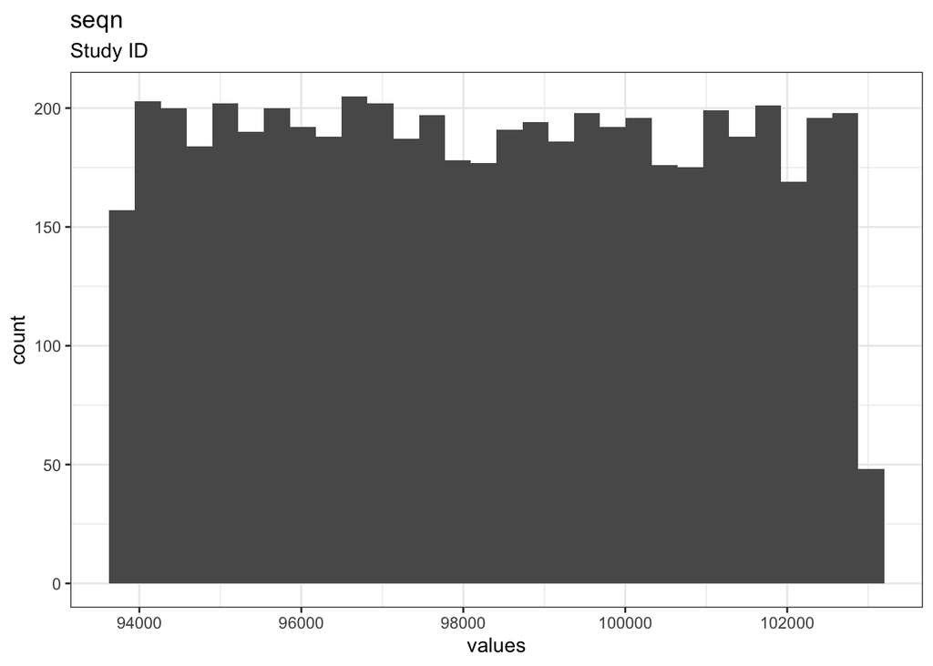

Distribution of values for seqn

0 missing values.

#### Summary statistics

| name | label | data_type | n_missing | complete_rate | min | median | max | mean | sd | hist | format.stata |
| --- | --- | --- | --- | --- | --- | --- | --- | --- | --- | --- | --- |
| seqn | Study ID | numeric | 0 | 1 | 93705 | 98274 | 1e+05 | 98288.24 | 2687.213 | ▇▇▇▇▇ | %10.0g |

### bmi

Body Mass Index

#### Distribution

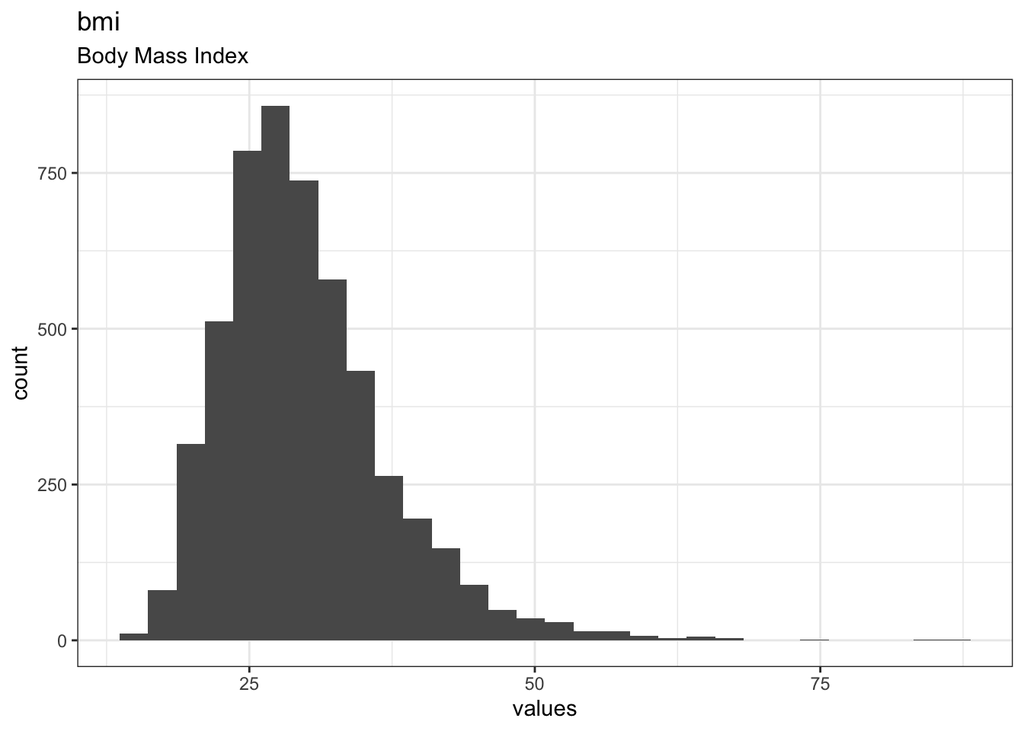

Distribution of values for bmi

394 missing values.

#### Summary statistics

| name | label | data_type | n_missing | complete_rate | min | median | max | mean | sd | hist | format.stata |
| --- | --- | --- | --- | --- | --- | --- | --- | --- | --- | --- | --- |
| bmi | Body Mass Index | numeric | 394 | 0.9292512 | 14 | 29 | 86 | 29.85179 | 7.396302 | ▇▇▁▁▁ | %10.0g |

### gender

Gender

#### Distribution

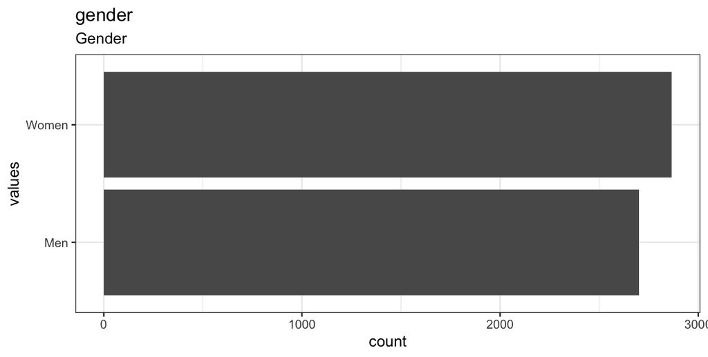

Distribution of values for gender

0 missing values.

#### Summary statistics

| name | label | data_type | ordered | value_labels | n_missing | complete_rate | n_unique | top_counts |
| --- | --- | --- | --- | --- | --- | --- | --- | --- |
| gender | Gender | factor | FALSE | 1. Men, 2. Women | 0 | 1 | 2 | Wom: 2867, Men: 2702 |

### age

Age, yrs

#### Distribution

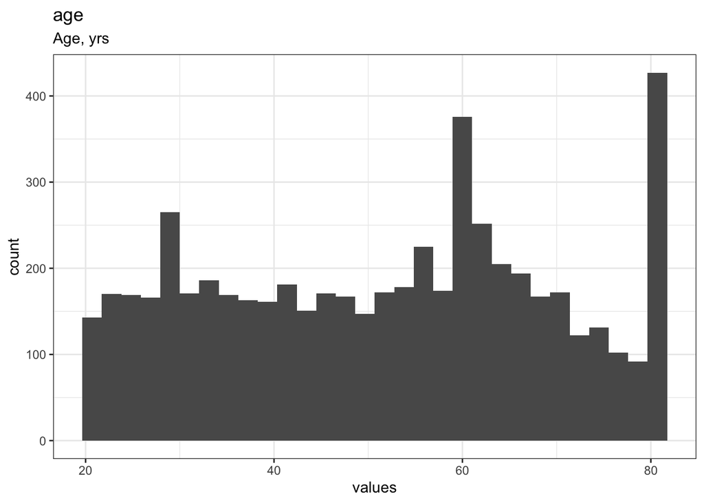

Distribution of values for age

0 missing values.

#### Summary statistics

| name | label | data_type | n_missing | complete_rate | min | median | max | mean | sd | hist |
| --- | --- | --- | --- | --- | --- | --- | --- | --- | --- | --- |
| age | Age, yrs | numeric | 0 | 1 | 20 | 53 | 80 | 51.50368 | 17.81285 | ▇▆▆▇▇ |

### race

Race/ethnicity

#### Distribution

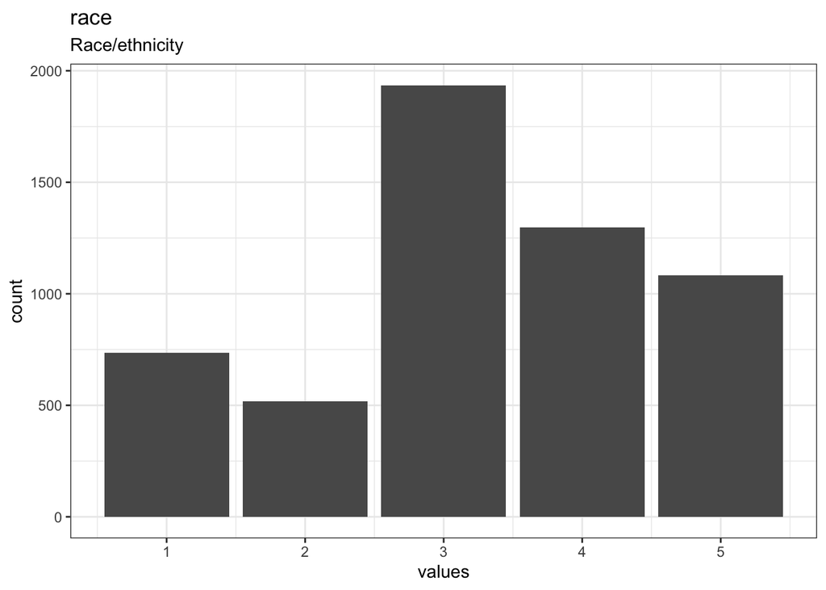

Distribution of values for race

0 missing values.

#### Summary statistics

| name | label | data_type | n_missing | complete_rate | min | median | max | mean | sd | hist |
| --- | --- | --- | --- | --- | --- | --- | --- | --- | --- | --- |
| race | Race/ethnicity | numeric | 0 | 1 | 1 | 3 | 5 | 3.265577 | 1.249872 | ▃▂▇▆▅ |

### edu

Education level - Adults 20+

#### Distribution

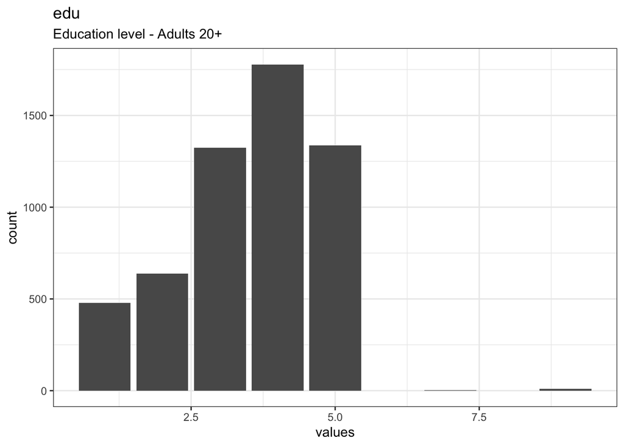

Distribution of values for edu

0 missing values.

#### Summary statistics

| name | label | data_type | n_missing | complete_rate | min | median | max | mean | sd | hist |
| --- | --- | --- | --- | --- | --- | --- | --- | --- | --- | --- |
| edu | Education level - Adults 20+ | numeric | 0 | 1 | 1 | 4 | 9 | 3.525768 | 1.240231 | ▃▇▃▁▁ |

### married

Marital Status

#### Distribution

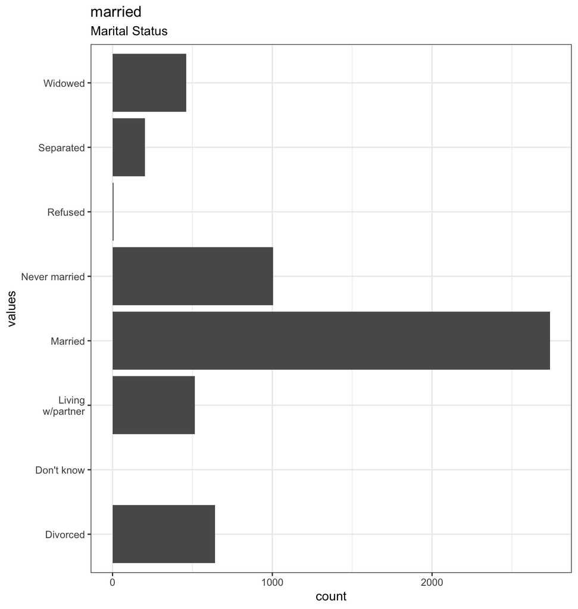

Distribution of values for married

0 missing values.

#### Summary statistics

| name | label | data_type | ordered | value_labels | n_missing | complete_rate | n_unique | top_counts |
| --- | --- | --- | --- | --- | --- | --- | --- | --- |
| married | Marital Status | factor | FALSE | 1. Married, 2. Widowed, 3. Divorced, 4. Separated, 5. Never married, 6. Living w/partner, 7. Refused, 8. Don’t know | 0 | 1 | 7 | Mar: 2737, Nev: 1006, Div: 641, Liv: 515 |

### income

Povery-income ratio

#### Distribution

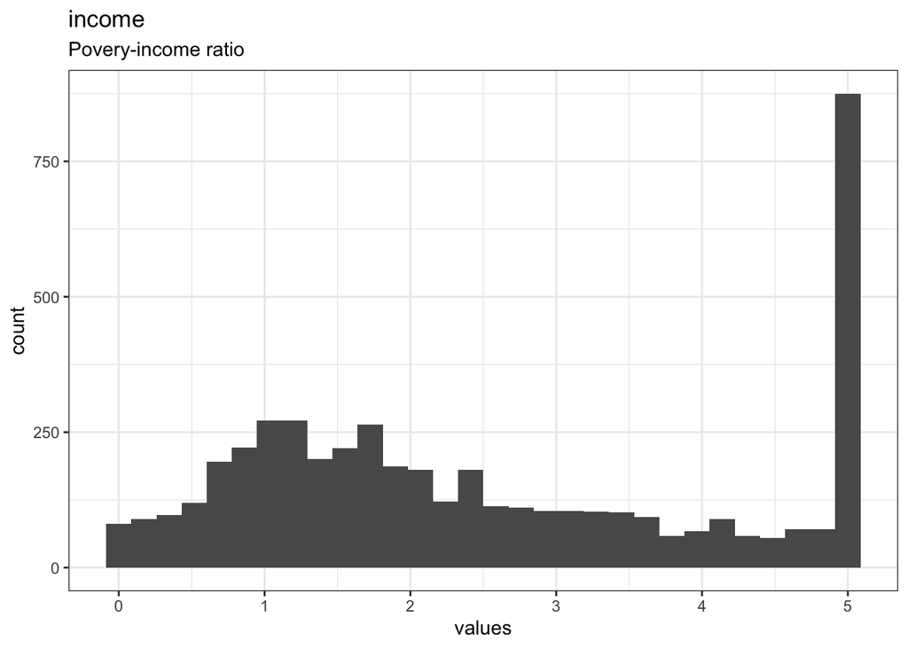

Distribution of values for income

791 missing values.

#### Summary statistics

| name | label | data_type | n_missing | complete_rate | min | median | max | mean | sd | hist |
| --- | --- | --- | --- | --- | --- | --- | --- | --- | --- | --- |
| income | Povery-income ratio | numeric | 791 | 0.8579637 | 0 | 2.1 | 5 | 2.555019 | 1.602175 | ▆▇▅▃▇ |

### sld_wd

Weekday sleep duration

#### Distribution

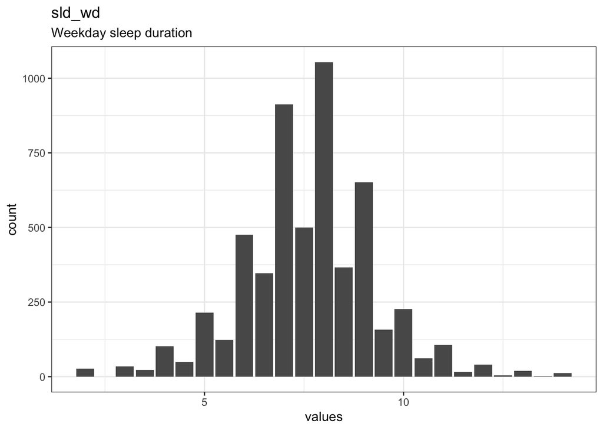

Distribution of values for sld_wd

47 missing values.

#### Summary statistics

| name | label | data_type | n_missing | complete_rate | min | median | max | mean | sd | hist |
| --- | --- | --- | --- | --- | --- | --- | --- | --- | --- | --- |
| sld_wd | Weekday sleep duration | numeric | 47 | 0.9915604 | 2 | 7.5 | 14 | 7.60422 | 1.664473 | ▁▃▇▁▁ |

### sld_we

Weekend sleep duration

#### Distribution

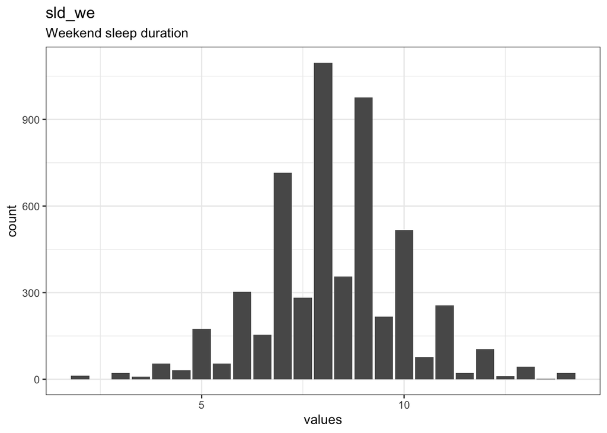

Distribution of values for sld_we

56 missing values.

#### Summary statistics

| name | label | data_type | n_missing | complete_rate | min | median | max | mean | sd | hist |
| --- | --- | --- | --- | --- | --- | --- | --- | --- | --- | --- |
| sld_we | Weekend sleep duration | numeric | 56 | 0.9899443 | 2 | 8 | 14 | 8.265917 | 1.742815 | ▁▂▇▂▁ |

### sl_time_wd

#### Distribution

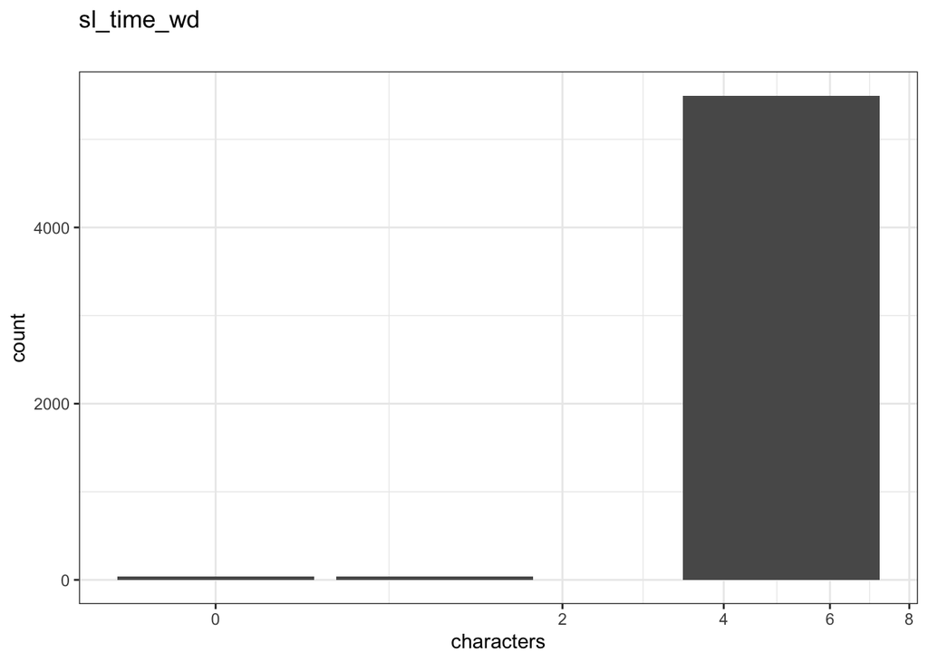

Distribution of values for sl_time_wd

0 missing values.

#### Summary statistics

| name | data_type | n_missing | complete_rate | n_unique | empty | min | max | whitespace | label |
| --- | --- | --- | --- | --- | --- | --- | --- | --- | --- |
| sl_time_wd | character | 0 | 1 | 57 | 37 | 0 | 5 | 0 | NA |

### wake_time_wd

#### Distribution

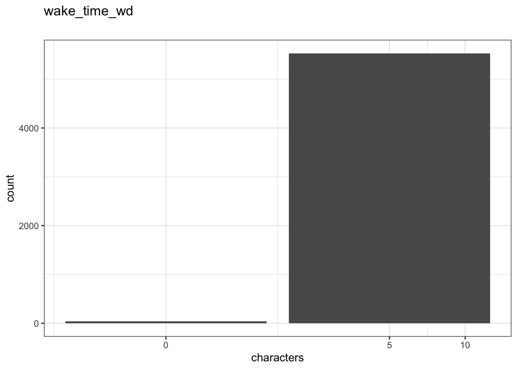

Distribution of values for wake_time_wd

0 missing values.

#### Summary statistics

| name | data_type | n_missing | complete_rate | n_unique | empty | min | max | whitespace | label |
| --- | --- | --- | --- | --- | --- | --- | --- | --- | --- |
| wake_time_wd | character | 0 | 1 | 101 | 39 | 0 | 5 | 0 | NA |

### sl_time_we

#### Distribution

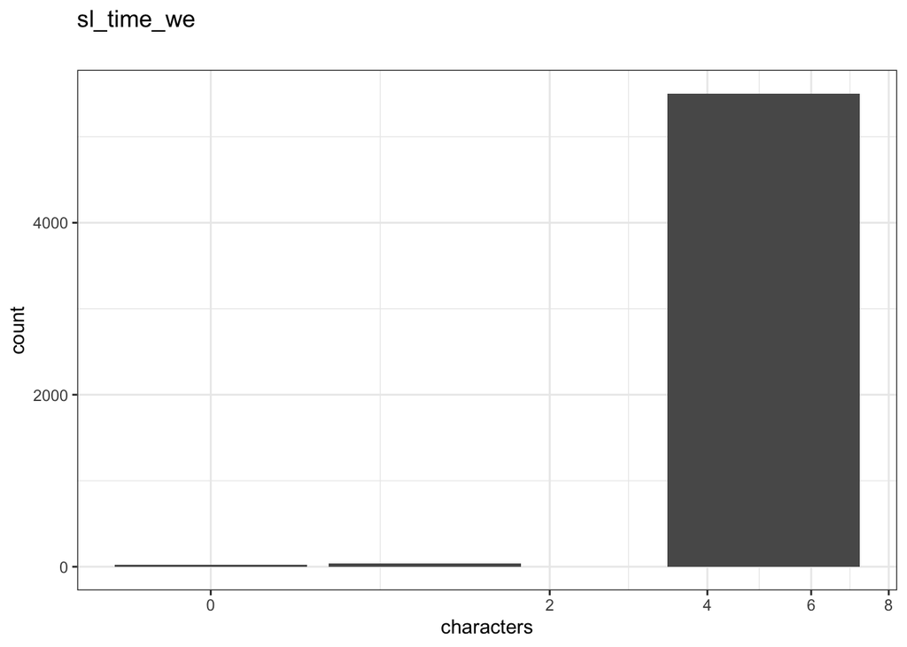

Distribution of values for sl_time_we

0 missing values.

#### Summary statistics

| name | data_type | n_missing | complete_rate | n_unique | empty | min | max | whitespace | label |
| --- | --- | --- | --- | --- | --- | --- | --- | --- | --- |
| sl_time_we | character | 0 | 1 | 60 | 26 | 0 | 5 | 0 | NA |

### wake_time_we

#### Distribution

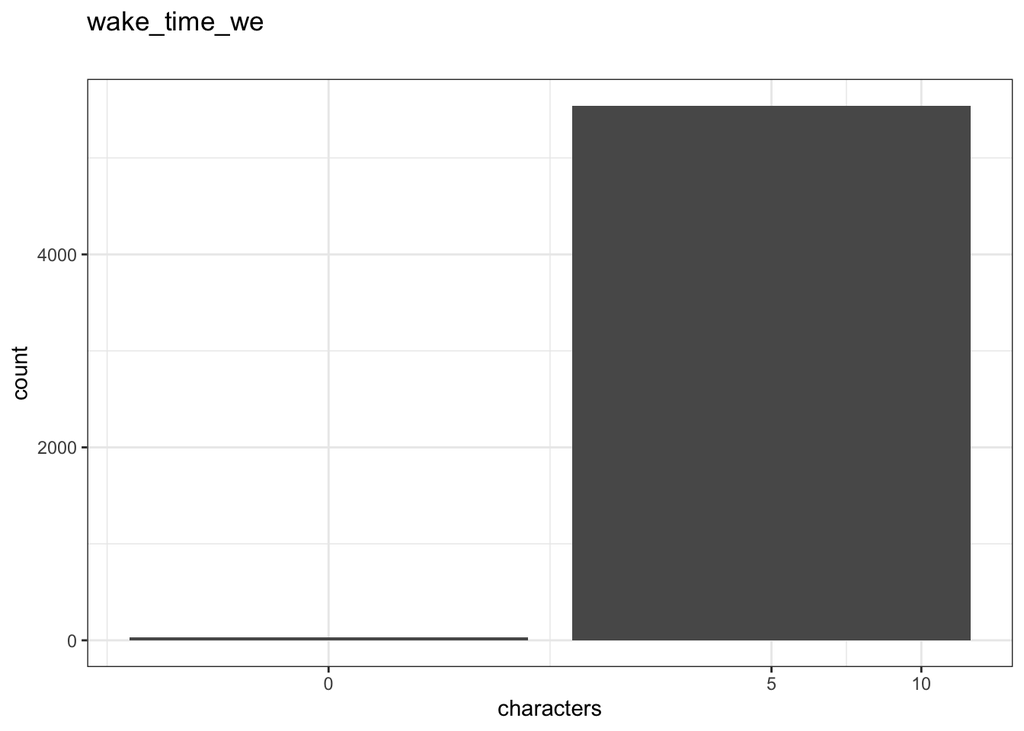

Distribution of values for wake_time_we

0 missing values.

#### Summary statistics

| name | data_type | n_missing | complete_rate | n_unique | empty | min | max | whitespace | label |
| --- | --- | --- | --- | --- | --- | --- | --- | --- | --- |
| wake_time_we | character | 0 | 1 | 67 | 27 | 0 | 5 | 0 | NA |

### sl_midpoint

#### Distribution

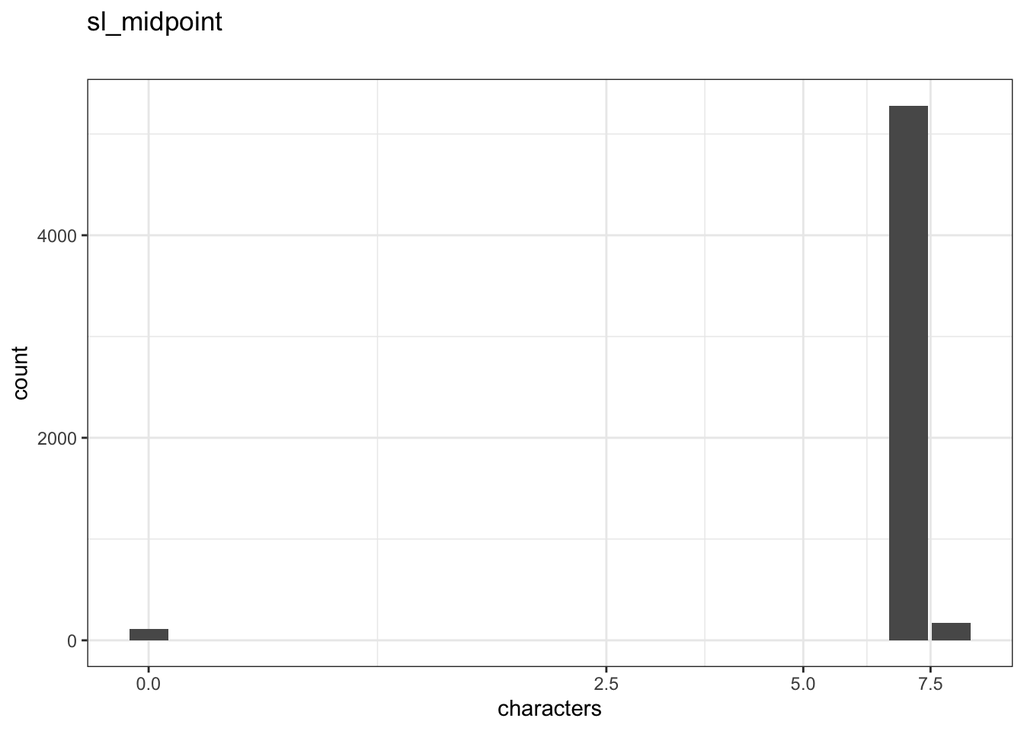

Distribution of values for sl_midpoint

0 missing values.

#### Summary statistics

| name | data_type | n_missing | complete_rate | n_unique | empty | min | max | whitespace | label |
| --- | --- | --- | --- | --- | --- | --- | --- | --- | --- |
| sl_midpoint | character | 0 | 1 | 352 | 115 | 0 | 8 | 0 | NA |

### paq605

Vigorous work activity

#### Distribution

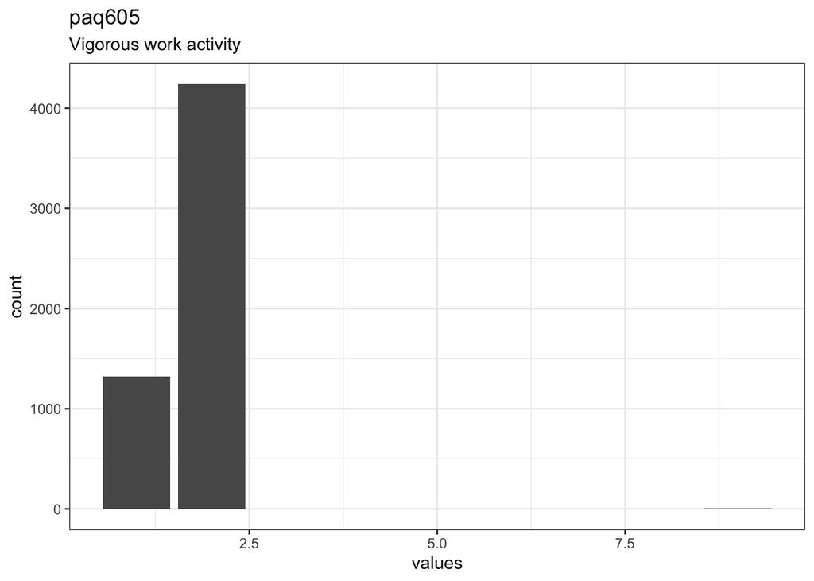

Distribution of values for paq605

0 missing values.

#### Summary statistics

| name | label | data_type | n_missing | complete_rate | min | median | max | mean | sd | hist |
| --- | --- | --- | --- | --- | --- | --- | --- | --- | --- | --- |
| paq605 | Vigorous work activity | numeric | 0 | 1 | 1 | 2 | 9 | 1.770336 | 0.4871295 | ▇▁▁▁▁ |

### paq610

Number of days vigorous work

#### Distribution

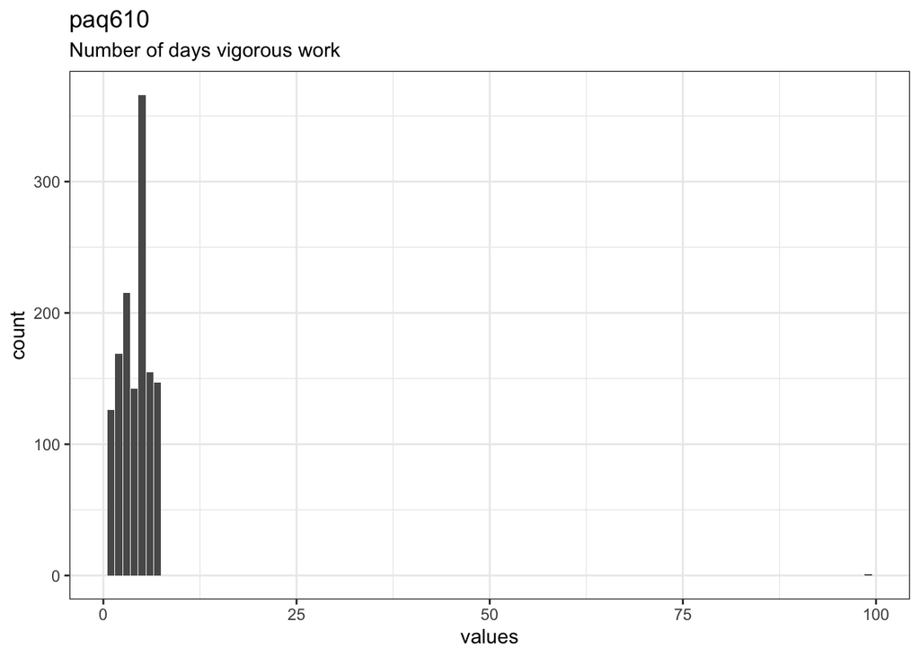

Distribution of values for paq610

4248 missing values.

#### Summary statistics

| name | label | data_type | n_missing | complete_rate | min | median | max | mean | sd | hist |
| --- | --- | --- | --- | --- | --- | --- | --- | --- | --- | --- |
| paq610 | Number of days vigorous work | numeric | 4248 | 0.237206 | 1 | 5 | 99 | 4.212718 | 3.174141 | ▇▁▁▁▁ |

### pad615

Minutes vigorous-intensity work

#### Distribution

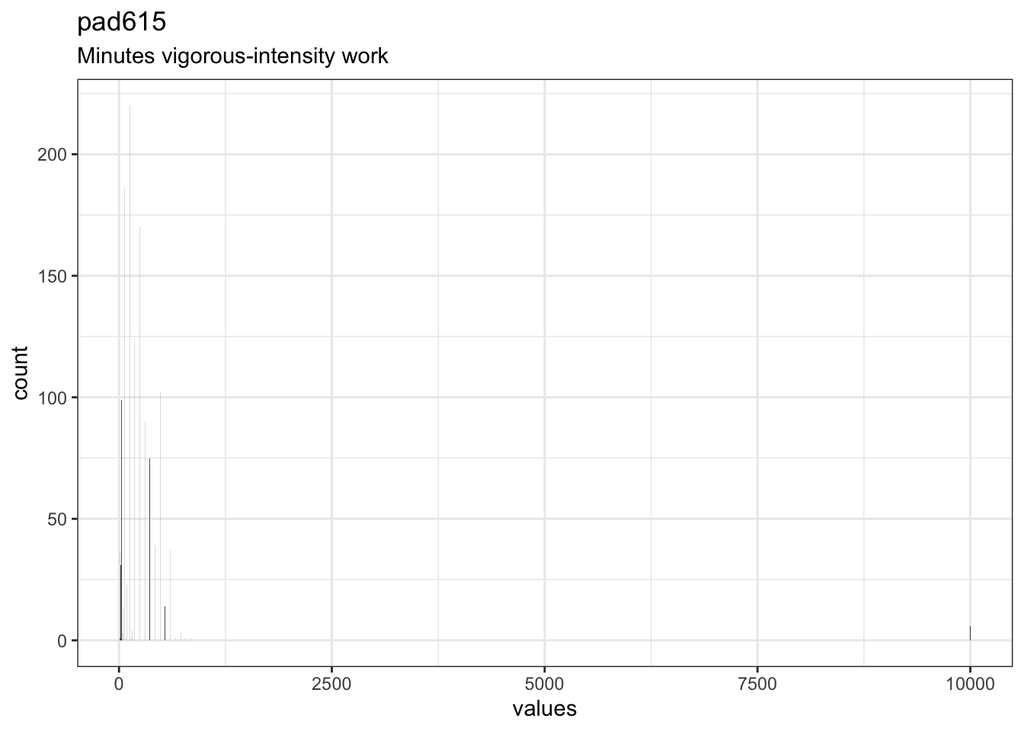

Distribution of values for pad615

4256 missing values.

#### Summary statistics

| name | label | data_type | n_missing | complete_rate | min | median | max | mean | sd | hist |
| --- | --- | --- | --- | --- | --- | --- | --- | --- | --- | --- |
| pad615 | Minutes vigorous-intensity work | numeric | 4256 | 0.2357694 | 10 | 180 | 9999 | 245.4615 | 680.6182 | ▇▁▁▁▁ |

### paq620

Moderate work activity

#### Distribution

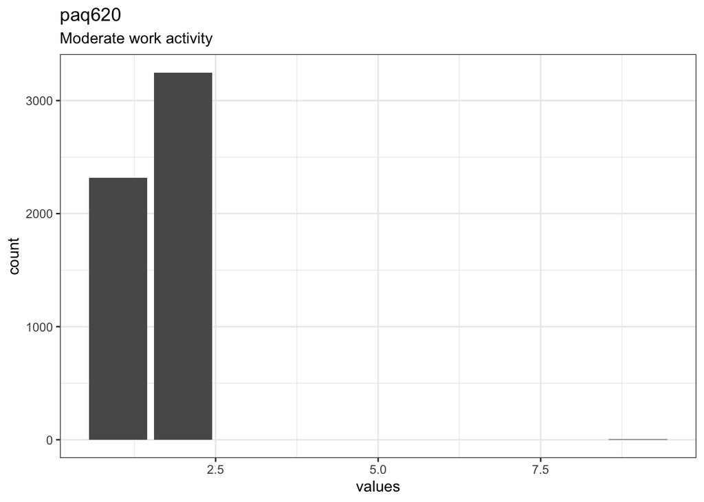

Distribution of values for paq620

0 missing values.

#### Summary statistics

| name | label | data_type | n_missing | complete_rate | min | median | max | mean | sd | hist |
| --- | --- | --- | --- | --- | --- | --- | --- | --- | --- | --- |
| paq620 | Moderate work activity | numeric | 0 | 1 | 1 | 2 | 9 | 1.590411 | 0.5405151 | ▇▁▁▁▁ |

### paq625

Number of days moderate work

#### Distribution

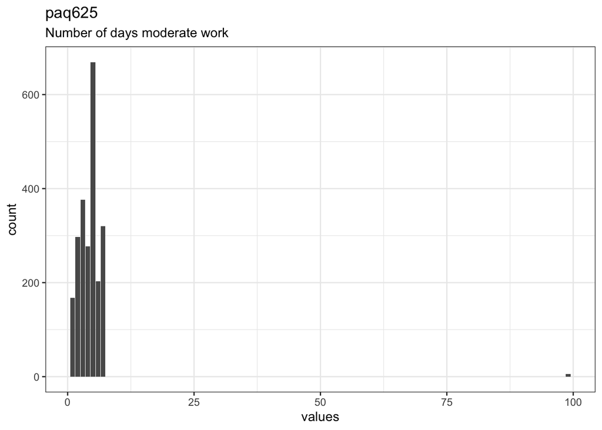

Distribution of values for paq625

3253 missing values.

#### Summary statistics

| name | label | data_type | n_missing | complete_rate | min | median | max | mean | sd | hist |
| --- | --- | --- | --- | --- | --- | --- | --- | --- | --- | --- |
| paq625 | Number of days moderate work | numeric | 3253 | 0.4158736 | 1 | 5 | 99 | 4.488342 | 5.134674 | ▇▁▁▁▁ |

### pad630

Minutes moderate-intensity work

#### Distribution

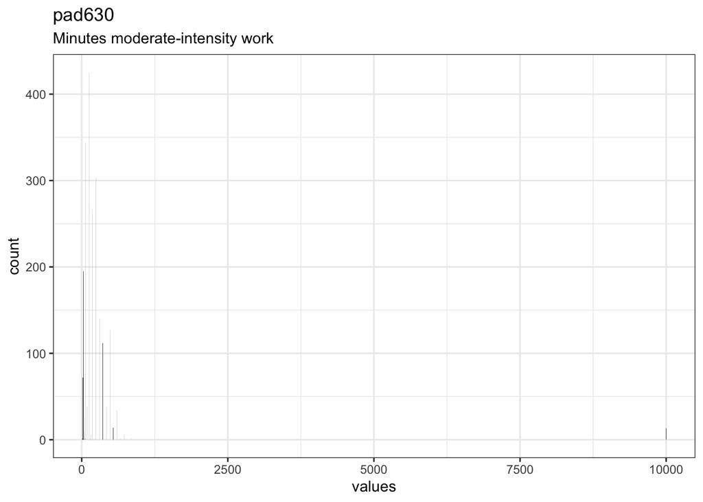

Distribution of values for pad630

3266 missing values.

#### Summary statistics

| name | label | data_type | n_missing | complete_rate | min | median | max | mean | sd | hist |
| --- | --- | --- | --- | --- | --- | --- | --- | --- | --- | --- |
| pad630 | Minutes moderate-intensity work | numeric | 3266 | 0.4135392 | 10 | 120 | 9999 | 230.3578 | 750.1591 | ▇▁▁▁▁ |

### paq635

Walk or bicycle

#### Distribution

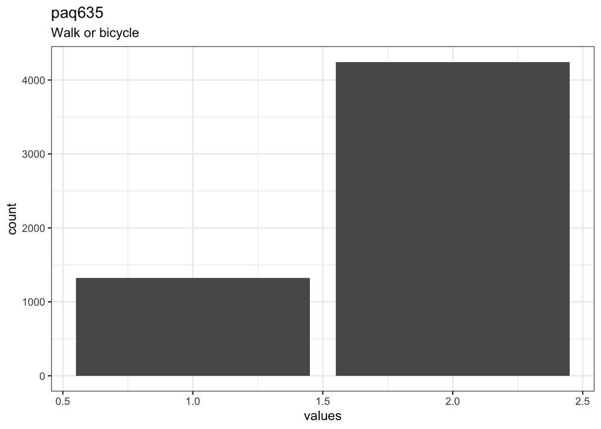

Distribution of values for paq635

0 missing values.

#### Summary statistics

| name | label | data_type | n_missing | complete_rate | min | median | max | mean | sd | hist |
| --- | --- | --- | --- | --- | --- | --- | --- | --- | --- | --- |
| paq635 | Walk or bicycle | numeric | 0 | 1 | 1 | 2 | 2 | 1.762076 | 0.4258507 | ▂▁▁▁▇ |

### paq640

Number of days walk or bicycle

#### Distribution

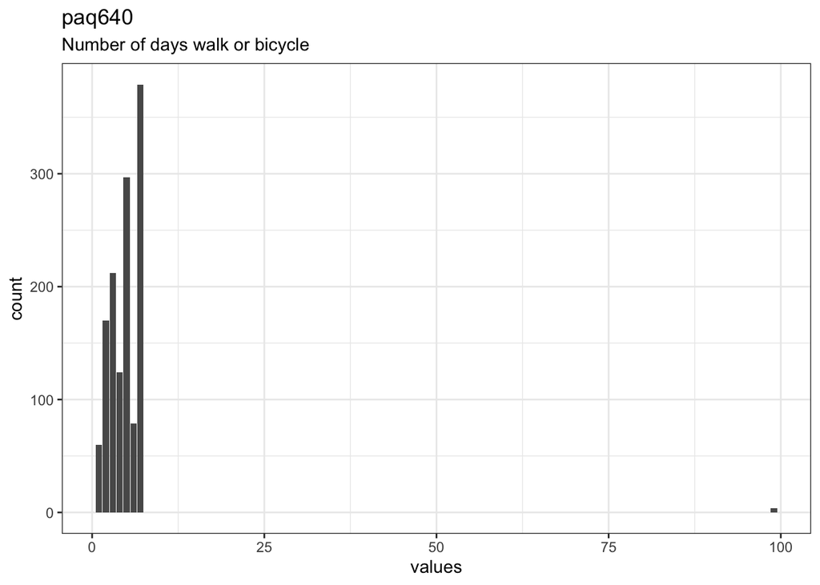

Distribution of values for paq640

4244 missing values.

#### Summary statistics

| name | label | data_type | n_missing | complete_rate | min | median | max | mean | sd | hist |
| --- | --- | --- | --- | --- | --- | --- | --- | --- | --- | --- |
| paq640 | Number of days walk or bicycle | numeric | 4244 | 0.2379242 | 1 | 5 | 99 | 4.935849 | 5.523607 | ▇▁▁▁▁ |

### pad645

Minutes walk/bicycle for transportation

#### Distribution

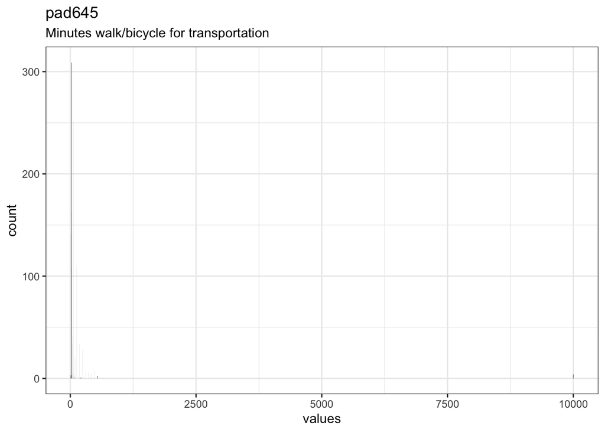

Distribution of values for pad645

4253 missing values.

#### Summary statistics

| name | label | data_type | n_missing | complete_rate | min | median | max | mean | sd | hist |
| --- | --- | --- | --- | --- | --- | --- | --- | --- | --- | --- |
| pad645 | Minutes walk/bicycle for transportation | numeric | 4253 | 0.2363081 | 10 | 30 | 9999 | 88.29255 | 552.387 | ▇▁▁▁▁ |

### paq650

Lesiure Vigorous PA

#### Distribution

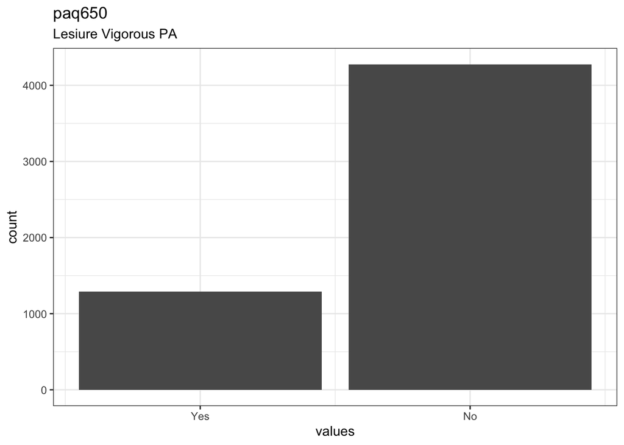

Distribution of values for paq650

0 missing values.

#### Summary statistics

| name | label | data_type | n_missing | complete_rate | min | median | max | mean | sd | n_value_labels | hist |
| --- | --- | --- | --- | --- | --- | --- | --- | --- | --- | --- | --- |
| paq650 | Lesiure Vigorous PA | haven_labelled | 0 | 1 | 1 | 2 | 2 | 1.767822 | 0.4222599 | 2 | ▂▁▁▁▁▁▁▇ |

#### Value labels

Response choices

| name | value |
| --- | --- |
| Yes | 1 |
| No | 2 |

### paq655

Leisure Vigorous PA Frequency

#### Distribution

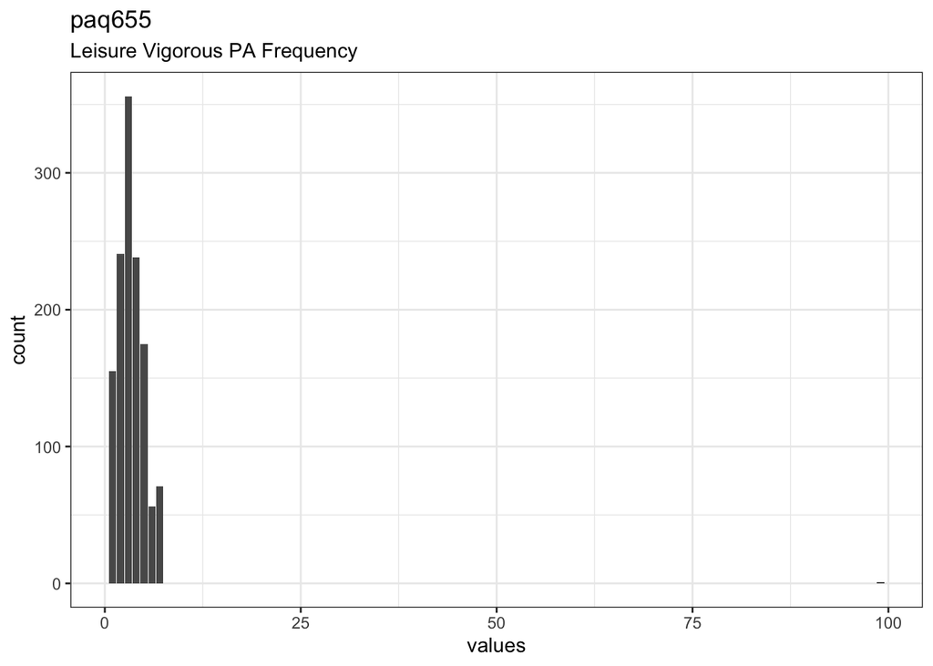

Distribution of values for paq655

4276 missing values.

#### Summary statistics

| name | label | data_type | n_missing | complete_rate | min | median | max | mean | sd | hist |
| --- | --- | --- | --- | --- | --- | --- | --- | --- | --- | --- |
| paq655 | Leisure Vigorous PA Frequency | numeric | 4276 | 0.2321781 | 1 | 3 | 99 | 3.452436 | 3.096778 | ▇▁▁▁▁ |

### pad660

Lesisure Vigorous PA Minutes

#### Distribution

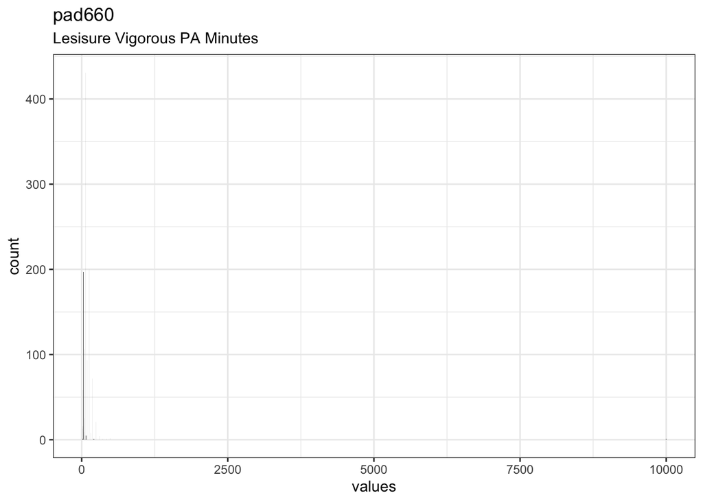

Distribution of values for pad660

4279 missing values.

#### Summary statistics

| name | label | data_type | n_missing | complete_rate | min | median | max | mean | sd | hist |
| --- | --- | --- | --- | --- | --- | --- | --- | --- | --- | --- |
| pad660 | Lesisure Vigorous PA Minutes | numeric | 4279 | 0.2316394 | 10 | 60 | 9999 | 81.75194 | 281.2817 | ▇▁▁▁▁ |

### paq665

Lesiure Moderate PA

#### Distribution

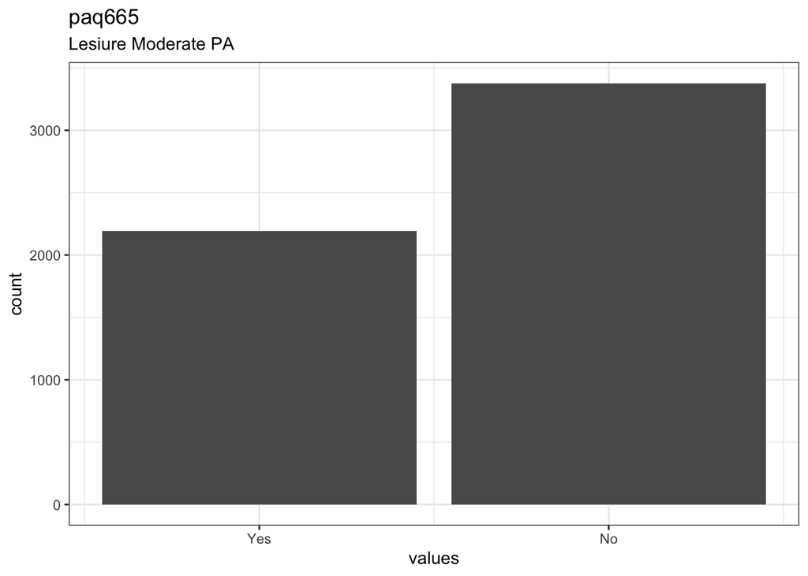

Distribution of values for paq665

0 missing values.

#### Summary statistics

| name | label | data_type | n_missing | complete_rate | min | median | max | mean | sd | n_value_labels | hist |
| --- | --- | --- | --- | --- | --- | --- | --- | --- | --- | --- | --- |
| paq665 | Lesiure Moderate PA | haven_labelled | 0 | 1 | 1 | 2 | 2 | 1.606392 | 0.4885934 | 2 | ▅▁▁▁▁▁▁▇ |

#### Value labels

Response choices

| name | value |
| --- | --- |
| Yes | 1 |
| No | 2 |

### paq670

Leisure Moderate PA Frequency

#### Distribution

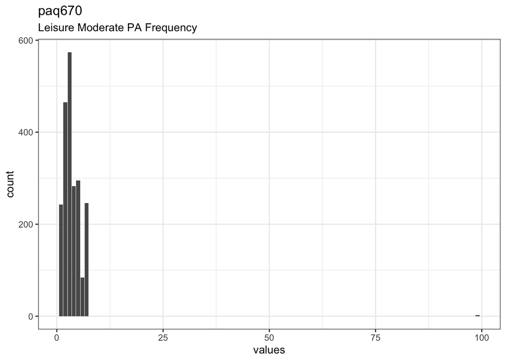

Distribution of values for paq670

3377 missing values.

#### Summary statistics

| name | label | data_type | n_missing | complete_rate | min | median | max | mean | sd | hist |
| --- | --- | --- | --- | --- | --- | --- | --- | --- | --- | --- |
| paq670 | Leisure Moderate PA Frequency | numeric | 3377 | 0.3936075 | 1 | 3 | 99 | 3.615876 | 3.3909 | ▇▁▁▁▁ |

### pad675

Lesisure Moderate PA Minutes

#### Distribution

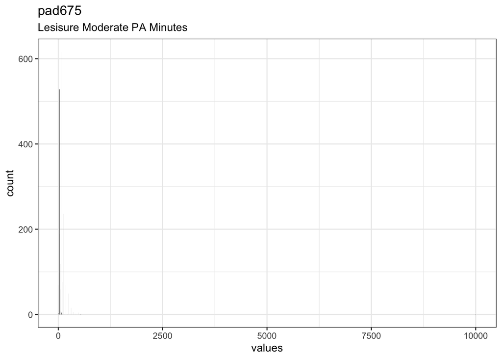

Distribution of values for pad675

3383 missing values.

#### Summary statistics

| name | label | data_type | n_missing | complete_rate | min | median | max | mean | sd | hist |
| --- | --- | --- | --- | --- | --- | --- | --- | --- | --- | --- |
| pad675 | Lesisure Moderate PA Minutes | numeric | 3383 | 0.3925301 | 10 | 50 | 9999 | 67.83532 | 220.3331 | ▇▁▁▁▁ |

### pad680

Sedentary minutes

#### Distribution

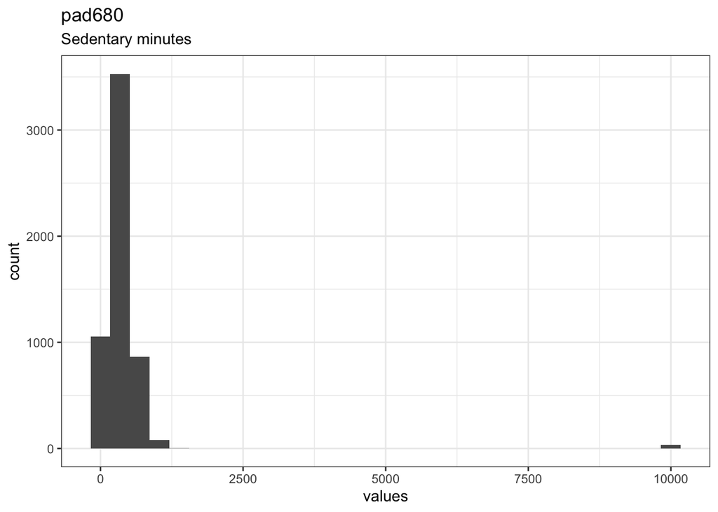

Distribution of values for pad680

10 missing values.

#### Summary statistics

| name | label | data_type | n_missing | complete_rate | min | median | max | mean | sd | hist |
| --- | --- | --- | --- | --- | --- | --- | --- | --- | --- | --- |
| pad680 | Sedentary minutes | numeric | 10 | 0.9982043 | 0 | 300 | 9999 | 389.4695 | 779.8728 | ▇▁▁▁▁ |

### dpq010

Little interest doing things

#### Distribution

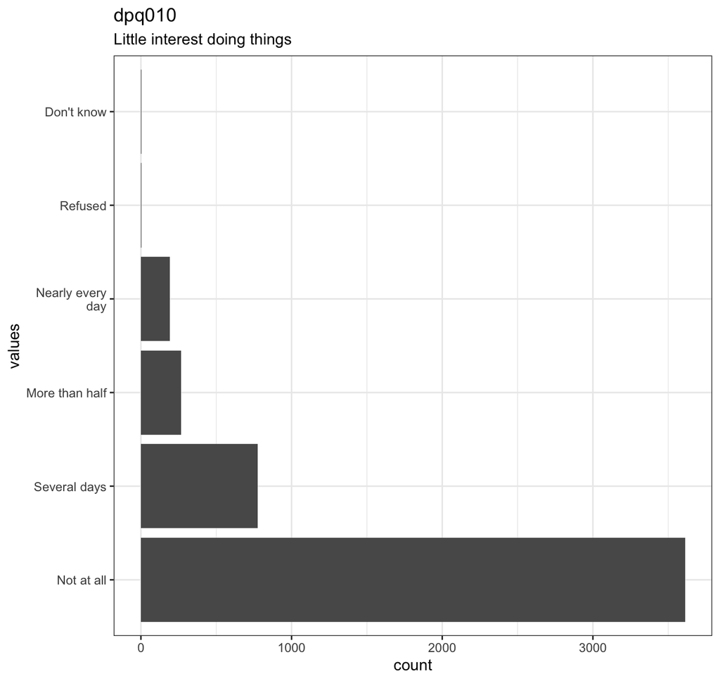

Distribution of values for dpq010

719 missing values.

#### Summary statistics

| name | label | data_type | ordered | value_labels | n_missing | complete_rate | n_unique | top_counts |
| --- | --- | --- | --- | --- | --- | --- | --- | --- |
| dpq010 | Little interest doing things | factor | FALSE | 1. Not at all, 2. Several days, 3. More than half, 4. Nearly every day, 5. Refused, 6. Don’t know | 719 | 0.8708924 | 6 | Not: 3611, Sev: 774, Mor: 265, Nea: 193 |

### dpq020

Feeling down, depressed

#### Distribution

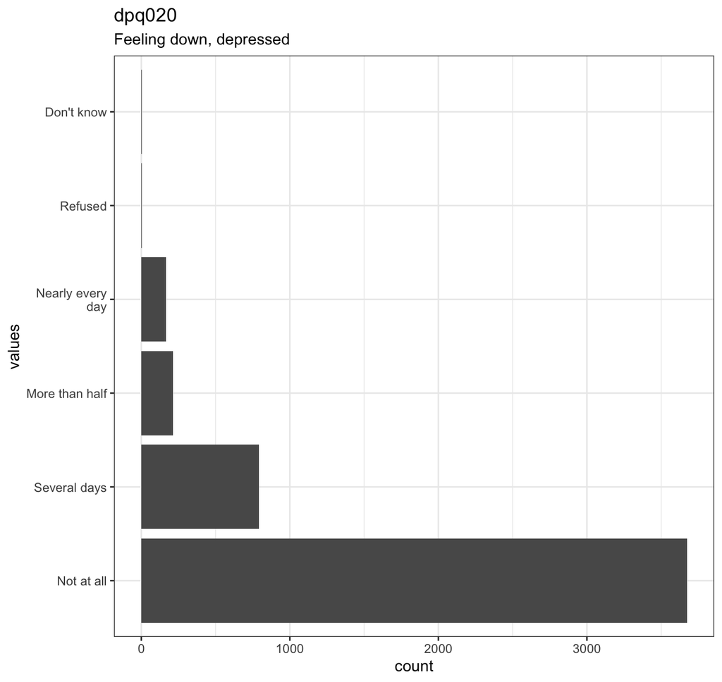

Distribution of values for dpq020

720 missing values.

#### Summary statistics

| name | label | data_type | ordered | value_labels | n_missing | complete_rate | n_unique | top_counts |
| --- | --- | --- | --- | --- | --- | --- | --- | --- |
| dpq020 | Feeling down, depressed | factor | FALSE | 1. Not at all, 2. Several days, 3. More than half, 4. Nearly every day, 5. Refused, 6. Don’t know | 720 | 0.8707129 | 6 | Not: 3673, Sev: 793, Mor: 212, Nea: 165 |

### dpq030

Trouble sleeping

#### Distribution

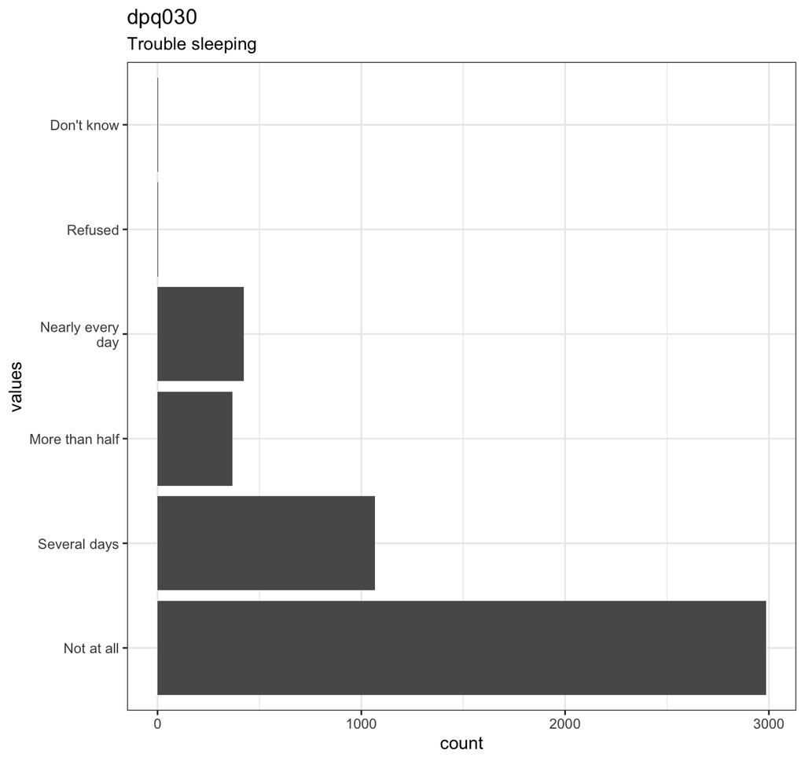

Distribution of values for dpq030

720 missing values.

#### Summary statistics

| name | label | data_type | ordered | value_labels | n_missing | complete_rate | n_unique | top_counts |
| --- | --- | --- | --- | --- | --- | --- | --- | --- |
| dpq030 | Trouble sleeping | factor | FALSE | 1. Not at all, 2. Several days, 3. More than half, 4. Nearly every day, 5. Refused, 6. Don’t know | 720 | 0.8707129 | 6 | Not: 2985, Sev: 1068, Nea: 423, Mor: 366 |

### dpq040

Low energy

#### Distribution

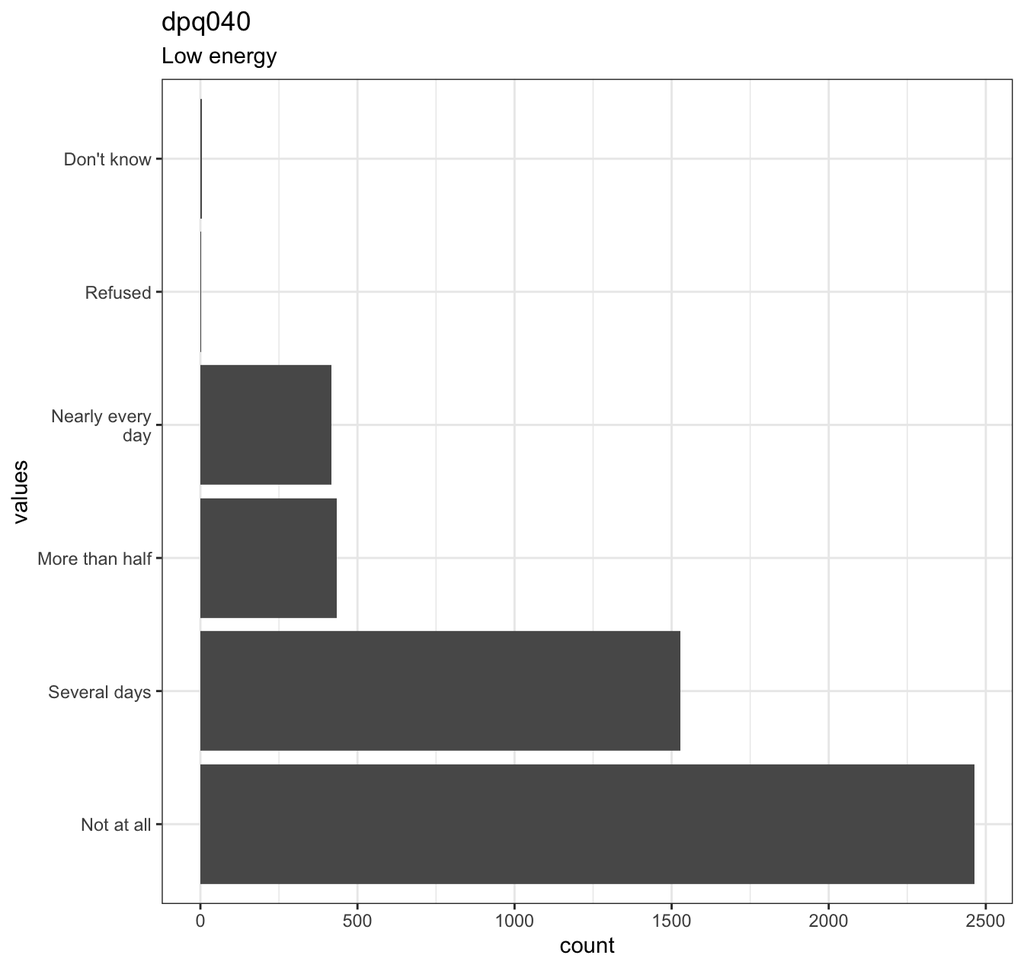

Distribution of values for dpq040

721 missing values.

#### Summary statistics

| name | label | data_type | ordered | value_labels | n_missing | complete_rate | n_unique | top_counts |
| --- | --- | --- | --- | --- | --- | --- | --- | --- |
| dpq040 | Low energy | factor | FALSE | 1. Not at all, 2. Several days, 3. More than half, 4. Nearly every day, 5. Refused, 6. Don’t know | 721 | 0.8705333 | 6 | Not: 2463, Sev: 1529, Mor: 433, Nea: 416 |

### dpq050

Low or high appetite

#### Distribution

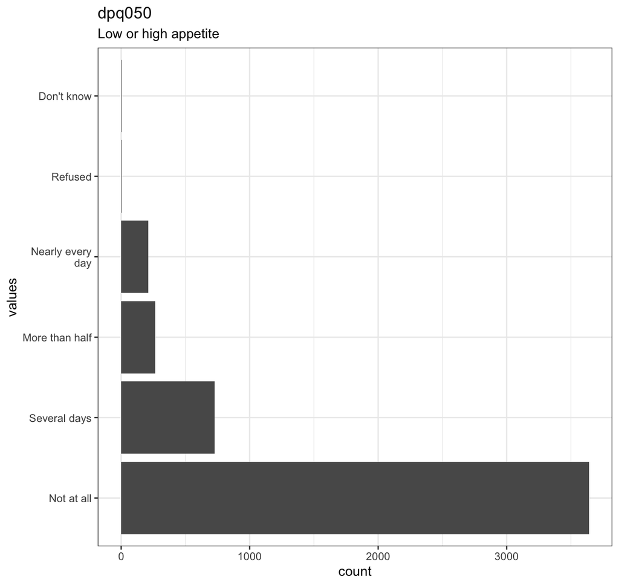

Distribution of values for dpq050

721 missing values.

#### Summary statistics

| name | label | data_type | ordered | value_labels | n_missing | complete_rate | n_unique | top_counts |
| --- | --- | --- | --- | --- | --- | --- | --- | --- |
| dpq050 | Low or high appetite | factor | FALSE | 1. Not at all, 2. Several days, 3. More than half, 4. Nearly every day, 5. Refused, 6. Don’t know | 721 | 0.8705333 | 6 | Not: 3640, Sev: 726, Mor: 265, Nea: 212 |

### dpq060

Feeling bad about self

#### Distribution

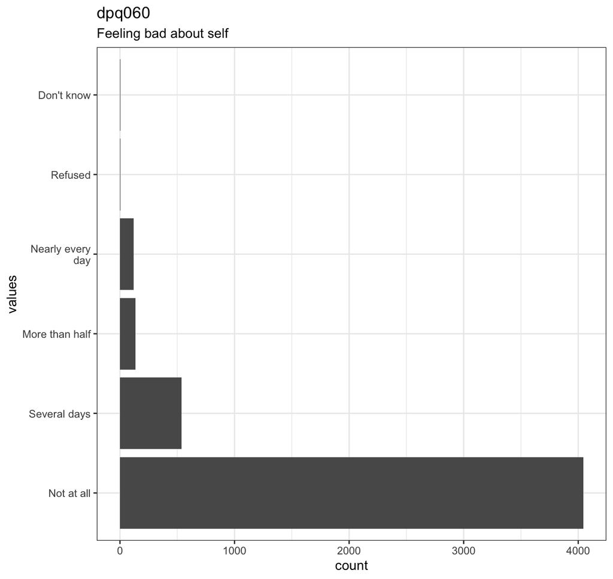

Distribution of values for dpq060

722 missing values.

#### Summary statistics

| name | label | data_type | ordered | value_labels | n_missing | complete_rate | n_unique | top_counts |
| --- | --- | --- | --- | --- | --- | --- | --- | --- |
| dpq060 | Feeling bad about self | factor | FALSE | 1. Not at all, 2. Several days, 3. More than half, 4. Nearly every day, 5. Refused, 6. Don’t know | 722 | 0.8703537 | 6 | Not: 4043, Sev: 539, Mor: 137, Nea: 120 |

### dpq070

Trouble concentrating

#### Distribution

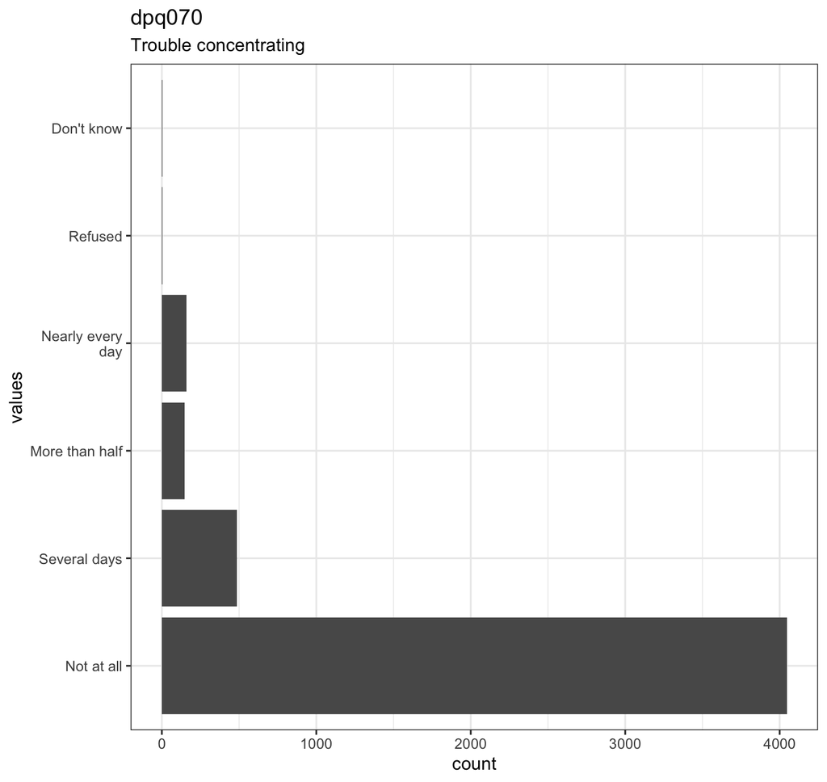

Distribution of values for dpq070

722 missing values.

#### Summary statistics

| name | label | data_type | ordered | value_labels | n_missing | complete_rate | n_unique | top_counts |
| --- | --- | --- | --- | --- | --- | --- | --- | --- |
| dpq070 | Trouble concentrating | factor | FALSE | 1. Not at all, 2. Several days, 3. More than half, 4. Nearly every day, 5. Refused, 6. Don’t know | 722 | 0.8703537 | 6 | Not: 4046, Sev: 487, Nea: 160, Mor: 149 |

### dpq080

Moving/speaking slow/fast

#### Distribution

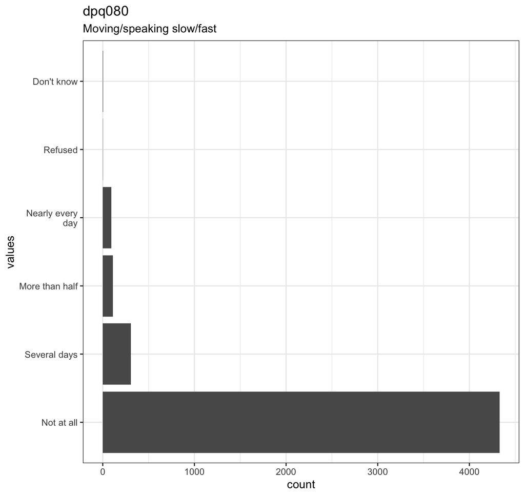

Distribution of values for dpq080

722 missing values.

#### Summary statistics

| name | label | data_type | ordered | value_labels | n_missing | complete_rate | n_unique | top_counts |
| --- | --- | --- | --- | --- | --- | --- | --- | --- |
| dpq080 | Moving/speaking slow/fast | factor | FALSE | 1. Not at all, 2. Several days, 3. More than half, 4. Nearly every day, 5. Refused, 6. Don’t know | 722 | 0.8703537 | 6 | Not: 4328, Sev: 308, Mor: 110, Nea: 94 |

### dpq090

Suicidal thoughts

#### Distribution

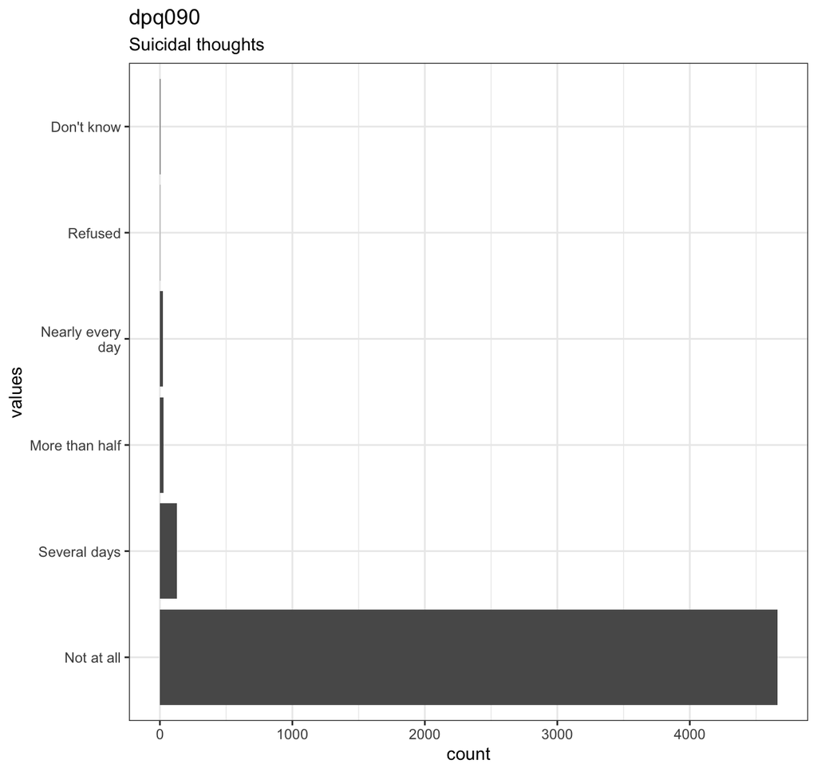

Distribution of values for dpq090

723 missing values.

#### Summary statistics

| name | label | data_type | ordered | value_labels | n_missing | complete_rate | n_unique | top_counts |
| --- | --- | --- | --- | --- | --- | --- | --- | --- |
| dpq090 | Suicidal thoughts | factor | FALSE | 1. Not at all, 2. Several days, 3. More than half, 4. Nearly every day, 5. Refused, 6. Don’t know | 723 | 0.8701742 | 6 | Not: 4660, Sev: 129, Mor: 29, Nea: 23 |

### dpq100

Experiencing difficulty

#### Distribution

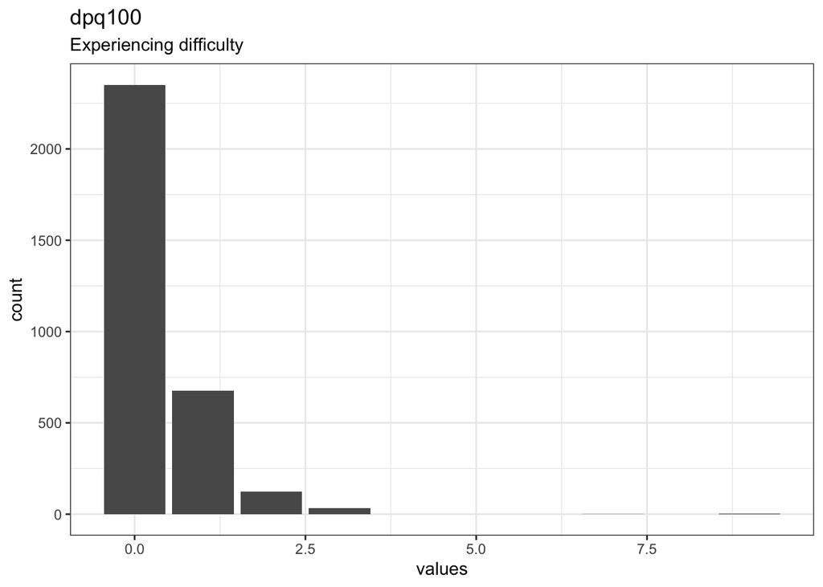

Distribution of values for dpq100

2382 missing values.

#### Summary statistics

| name | label | data_type | n_missing | complete_rate | min | median | max | mean | sd | hist |
| --- | --- | --- | --- | --- | --- | --- | --- | --- | --- | --- |
| dpq100 | Experiencing difficulty | numeric | 2382 | 0.5722751 | 0 | 0 | 9 | 0.3282083 | 0.6457875 | ▇▁▁▁▁ |

## Missingness report

| description | pad680 | sld_wd | sld_we | bmi | dpq010 | dpq020 | dpq030 | dpq040 | dpq050 | dpq060 | dpq070 | dpq080 | dpq090 | income | dpq100 | paq625 | pad630 | paq670 | pad675 | paq640 | paq610 | pad645 | pad615 | paq655 | pad660 | var_miss | n_miss |
| --- | --- | --- | --- | --- | --- | --- | --- | --- | --- | --- | --- | --- | --- | --- | --- | --- | --- | --- | --- | --- | --- | --- | --- | --- | --- | --- | --- |
| Missing values per variable | 10 | 47 | 56 | 394 | 719 | 720 | 720 | 721 | 721 | 722 | 722 | 722 | 723 | 791 | 2382 | 3253 | 3266 | 3377 | 3383 | 4244 | 4248 | 4253 | 4256 | 4276 | 4279 | 49005 | 49005 |
| Missing values in 10 variables | 1 | 1 | 1 | 1 | 1 | 1 | 1 | 1 | 1 | 1 | 1 | 1 | 1 | 1 | 1 | 0 | 0 | 0 | 0 | 0 | 0 | 0 | 0 | 0 | 0 | 10 | 705 |
| Missing values in 11 variables | 1 | 1 | 1 | 1 | 1 | 1 | 1 | 1 | 1 | 1 | 1 | 1 | 1 | 1 | 0 | 0 | 0 | 0 | 0 | 0 | 0 | 0 | 0 | 0 | 0 | 11 | 326 |
| Missing values in 8 variables | 1 | 1 | 1 | 1 | 1 | 1 | 1 | 1 | 1 | 1 | 1 | 1 | 1 | 1 | 1 | 1 | 1 | 0 | 0 | 0 | 0 | 0 | 0 | 0 | 0 | 8 | 287 |
| Missing values in 6 variables | 1 | 1 | 1 | 1 | 1 | 1 | 1 | 1 | 1 | 1 | 1 | 1 | 1 | 1 | 1 | 1 | 1 | 0 | 0 | 0 | 1 | 0 | 1 | 0 | 0 | 6 | 220 |
| Missing values in 8 variables | 1 | 1 | 1 | 1 | 1 | 1 | 1 | 1 | 1 | 1 | 1 | 1 | 1 | 1 | 1 | 0 | 0 | 1 | 1 | 0 | 0 | 0 | 0 | 0 | 0 | 8 | 198 |
| Missing values in 8 variables | 1 | 1 | 1 | 1 | 1 | 1 | 1 | 1 | 1 | 1 | 1 | 1 | 1 | 1 | 1 | 0 | 0 | 0 | 0 | 1 | 0 | 1 | 0 | 0 | 0 | 8 | 139 |
| Missing values in 9 variables | 1 | 1 | 1 | 1 | 1 | 1 | 1 | 1 | 1 | 1 | 1 | 1 | 1 | 1 | 0 | 0 | 0 | 1 | 1 | 0 | 0 | 0 | 0 | 0 | 0 | 9 | 133 |
| Missing values in 6 variables | 1 | 1 | 1 | 1 | 1 | 1 | 1 | 1 | 1 | 1 | 1 | 1 | 1 | 1 | 1 | 1 | 1 | 1 | 1 | 0 | 0 | 0 | 0 | 0 | 0 | 6 | 131 |
| Missing values in 6 variables | 1 | 1 | 1 | 1 | 1 | 1 | 1 | 1 | 1 | 1 | 1 | 1 | 1 | 1 | 1 | 0 | 0 | 1 | 1 | 0 | 0 | 0 | 0 | 1 | 1 | 6 | 127 |

[output cut: 17 more lines]

## Codebook table

| name | label | data_type | ordered | value_labels | n_missing | complete_rate | n_unique | empty | top_counts | min | median | max | mean | sd | whitespace | n_value_labels | hist | format.stata |
| --- | --- | --- | --- | --- | --- | --- | --- | --- | --- | --- | --- | --- | --- | --- | --- | --- | --- | --- |
| seqn | Study ID | numeric | NA | NA | 0 | 1.0000000 | NA | NA | NA | 93705 | 98274.0 | 102956 | 9.828824e+04 | 2687.2130132 | NA | NA | ▇▇▇▇▇ | %10.0g |
| bmi | Body Mass Index | numeric | NA | NA | 394 | 0.9292512 | NA | NA | NA | 14 | 28.6 | 86 | 2.985179e+01 | 7.3963018 | NA | NA | ▇▇▁▁▁ | %10.0g |
| gender | Gender | factor | FALSE | 1. Men, 2. Women | 0 | 1.0000000 | 2 | NA | Wom: 2867, Men: 2702 | NA | NA | NA | NA | NA | NA | NA | NA | NA |
| age | Age, yrs | numeric | NA | NA | 0 | 1.0000000 | NA | NA | NA | 20 | 53.0 | 80 | 5.150368e+01 | 17.8128550 | NA | NA | ▇▆▆▇▇ | NA |
| race | Race/ethnicity | numeric | NA | NA | 0 | 1.0000000 | NA | NA | NA | 1 | 3.0 | 5 | 3.265577e+00 | 1.2498715 | NA | NA | ▃▂▇▆▅ | NA |
| edu | Education level - Adults 20+ | numeric | NA | NA | 0 | 1.0000000 | NA | NA | NA | 1 | 4.0 | 9 | 3.525768e+00 | 1.2402314 | NA | NA | ▃▇▃▁▁ | NA |
| married | Marital Status | factor | FALSE | 1. Married, 2. Widowed, 3. Divorced, 4. Separated, 5. Never married, 6. Living w/partner, 7. Refused, 8. Don’t know | 0 | 1.0000000 | 7 | NA | Mar: 2737, Nev: 1006, Div: 641, Liv: 515 | NA | NA | NA | NA | NA | NA | NA | NA | NA |
| income | Povery-income ratio | numeric | NA | NA | 791 | 0.8579637 | NA | NA | NA | 0 | 2.1 | 5 | 2.555019e+00 | 1.6021748 | NA | NA | ▆▇▅▃▇ | NA |
| sld_wd | Weekday sleep duration | numeric | NA | NA | 47 | 0.9915604 | NA | NA | NA | 2 | 7.5 | 14 | 7.604220e+00 | 1.6644733 | NA | NA | ▁▃▇▁▁ | NA |
| sld_we | Weekend sleep duration | numeric | NA | NA | 56 | 0.9899443 | NA | NA | NA | 2 | 8.0 | 14 | 8.265917e+00 | 1.7428147 | NA | NA | ▁▂▇▂▁ | NA |
| sl_time_wd | NA | character | NA | NA | 0 | 1.0000000 | 57 | 37 | NA | 0 | NA | 5 | NA | NA | 0 | NA | NA | NA |
| wake_time_wd | NA | character | NA | NA | 0 | 1.0000000 | 101 | 39 | NA | 0 | NA | 5 | NA | NA | 0 | NA | NA | NA |
| sl_time_we | NA | character | NA | NA | 0 | 1.0000000 | 60 | 26 | NA | 0 | NA | 5 | NA | NA | 0 | NA | NA | NA |
| wake_time_we | NA | character | NA | NA | 0 | 1.0000000 | 67 | 27 | NA | 0 | NA | 5 | NA | NA | 0 | NA | NA | NA |
| sl_midpoint | NA | character | NA | NA | 0 | 1.0000000 | 352 | 115 | NA | 0 | NA | 8 | NA | NA | 0 | NA | NA | NA |
| paq605 | Vigorous work activity | numeric | NA | NA | 0 | 1.0000000 | NA | NA | NA | 1 | 2.0 | 9 | 1.770336e+00 | 0.4871295 | NA | NA | ▇▁▁▁▁ | NA |
| paq610 | Number of days vigorous work | numeric | NA | NA | 4248 | 0.2372060 | NA | NA | NA | 1 | 5.0 | 99 | 4.212718e+00 | 3.1741411 | NA | NA | ▇▁▁▁▁ | NA |
| pad615 | Minutes vigorous-intensity work | numeric | NA | NA | 4256 | 0.2357694 | NA | NA | NA | 10 | 180.0 | 9999 | 2.454615e+02 | 680.6182349 | NA | NA | ▇▁▁▁▁ | NA |
| paq620 | Moderate work activity | numeric | NA | NA | 0 | 1.0000000 | NA | NA | NA | 1 | 2.0 | 9 | 1.590411e+00 | 0.5405151 | NA | NA | ▇▁▁▁▁ | NA |
| paq625 | Number of days moderate work | numeric | NA | NA | 3253 | 0.4158736 | NA | NA | NA | 1 | 5.0 | 99 | 4.488342e+00 | 5.1346738 | NA | NA | ▇▁▁▁▁ | NA |
| pad630 | Minutes moderate-intensity work | numeric | NA | NA | 3266 | 0.4135392 | NA | NA | NA | 10 | 120.0 | 9999 | 2.303578e+02 | 750.1591048 | NA | NA | ▇▁▁▁▁ | NA |
| paq635 | Walk or bicycle | numeric | NA | NA | 0 | 1.0000000 | NA | NA | NA | 1 | 2.0 | 2 | 1.762076e+00 | 0.4258507 | NA | NA | ▂▁▁▁▇ | NA |
| paq640 | Number of days walk or bicycle | numeric | NA | NA | 4244 | 0.2379242 | NA | NA | NA | 1 | 5.0 | 99 | 4.935849e+00 | 5.5236068 | NA | NA | ▇▁▁▁▁ | NA |
| pad645 | Minutes walk/bicycle for transportation | numeric | NA | NA | 4253 | 0.2363081 | NA | NA | NA | 10 | 30.0 | 9999 | 8.829255e+01 | 552.3869947 | NA | NA | ▇▁▁▁▁ | NA |
| paq650 | Lesiure Vigorous PA | haven_labelled | NA | 1. Yes, 2. No | 0 | 1.0000000 | NA | NA | NA | 1 | 2 | 2 | 1.767822e+00 | 0.4222599 | NA | 2 | ▂▁▁▁▁▁▁▇ | NA |
| paq655 | Leisure Vigorous PA Frequency | numeric | NA | NA | 4276 | 0.2321781 | NA | NA | NA | 1 | 3.0 | 99 | 3.452436e+00 | 3.0967781 | NA | NA | ▇▁▁▁▁ | NA |
| pad660 | Lesisure Vigorous PA Minutes | numeric | NA | NA | 4279 | 0.2316394 | NA | NA | NA | 10 | 60.0 | 9999 | 8.175194e+01 | 281.2816514 | NA | NA | ▇▁▁▁▁ | NA |
| paq665 | Lesiure Moderate PA | haven_labelled | NA | 1. Yes, 2. No | 0 | 1.0000000 | NA | NA | NA | 1 | 2 | 2 | 1.606392e+00 | 0.4885934 | NA | 2 | ▅▁▁▁▁▁▁▇ | NA |
| paq670 | Leisure Moderate PA Frequency | numeric | NA | NA | 3377 | 0.3936075 | NA | NA | NA | 1 | 3.0 | 99 | 3.615876e+00 | 3.3909003 | NA | NA | ▇▁▁▁▁ | NA |
| pad675 | Lesisure Moderate PA Minutes | numeric | NA | NA | 3383 | 0.3925301 | NA | NA | NA | 10 | 50.0 | 9999 | 6.783532e+01 | 220.3331186 | NA | NA | ▇▁▁▁▁ | NA |
| pad680 | Sedentary minutes | numeric | NA | NA | 10 | 0.9982043 | NA | NA | NA | 0 | 300.0 | 9999 | 3.894695e+02 | 779.8727661 | NA | NA | ▇▁▁▁▁ | NA |
| dpq010 | Little interest doing things | factor | FALSE | 1. Not at all, 2. Several days, 3. More than half, 4. Nearly every day, 5. Refused, 6. Don’t know | 719 | 0.8708924 | 6 | NA | Not: 3611, Sev: 774, Mor: 265, Nea: 193 | NA | NA | NA | NA | NA | NA | NA | NA | NA |
| dpq020 | Feeling down, depressed | factor | FALSE | 1. Not at all, 2. Several days, 3. More than half, 4. Nearly every day, 5. Refused, 6. Don’t know | 720 | 0.8707129 | 6 | NA | Not: 3673, Sev: 793, Mor: 212, Nea: 165 | NA | NA | NA | NA | NA | NA | NA | NA | NA |
| dpq030 | Trouble sleeping | factor | FALSE | 1. Not at all, 2. Several days, 3. More than half, 4. Nearly every day, 5. Refused, 6. Don’t know | 720 | 0.8707129 | 6 | NA | Not: 2985, Sev: 1068, Nea: 423, Mor: 366 | NA | NA | NA | NA | NA | NA | NA | NA | NA |
| dpq040 | Low energy | factor | FALSE | 1. Not at all, 2. Several days, 3. More than half, 4. Nearly every day, 5. Refused, 6. Don’t know | 721 | 0.8705333 | 6 | NA | Not: 2463, Sev: 1529, Mor: 433, Nea: 416 | NA | NA | NA | NA | NA | NA | NA | NA | NA |
| dpq050 | Low or high appetite | factor | FALSE | 1. Not at all, 2. Several days, 3. More than half, 4. Nearly every day, 5. Refused, 6. Don’t know | 721 | 0.8705333 | 6 | NA | Not: 3640, Sev: 726, Mor: 265, Nea: 212 | NA | NA | NA | NA | NA | NA | NA | NA | NA |
| dpq060 | Feeling bad about self | factor | FALSE | 1. Not at all, 2. Several days, 3. More than half, 4. Nearly every day, 5. Refused, 6. Don’t know | 722 | 0.8703537 | 6 | NA | Not: 4043, Sev: 539, Mor: 137, Nea: 120 | NA | NA | NA | NA | NA | NA | NA | NA | NA |
| dpq070 | Trouble concentrating | factor | FALSE | 1. Not at all, 2. Several days, 3. More than half, 4. Nearly every day, 5. Refused, 6. Don’t know | 722 | 0.8703537 | 6 | NA | Not: 4046, Sev: 487, Nea: 160, Mor: 149 | NA | NA | NA | NA | NA | NA | NA | NA | NA |
| dpq080 | Moving/speaking slow/fast | factor | FALSE | 1. Not at all, 2. Several days, 3. More than half, 4. Nearly every day, 5. Refused, 6. Don’t know | 722 | 0.8703537 | 6 | NA | Not: 4328, Sev: 308, Mor: 110, Nea: 94 | NA | NA | NA | NA | NA | NA | NA | NA | NA |
| dpq090 | Suicidal thoughts | factor | FALSE | 1. Not at all, 2. Several days, 3. More than half, 4. Nearly every day, 5. Refused, 6. Don’t know | 723 | 0.8701742 | 6 | NA | Not: 4660, Sev: 129, Mor: 29, Nea: 23 | NA | NA | NA | NA | NA | NA | NA | NA | NA |
| dpq100 | Experiencing difficulty | numeric | NA | NA | 2382 | 0.5722751 | NA | NA | NA | 0 | 0.0 | 9 | 3.282083e-01 | 0.6457875 | NA | NA | ▇▁▁▁▁ | NA |

**JSON-LD metadata**